# Composite Variables

Jon Lefcheck

November 16, 2018

## 1.1 What is a Composite Variable?

Composite variables are another way, besides latent variables, to represent complex concepts in structural equation modeling. The most important distinction between the two is that, while latent variables give rise to measurable manifestations of an unobservable concept, composite variables arise from the combined influence of other variables.

Consider the following composite variable $\eta$:

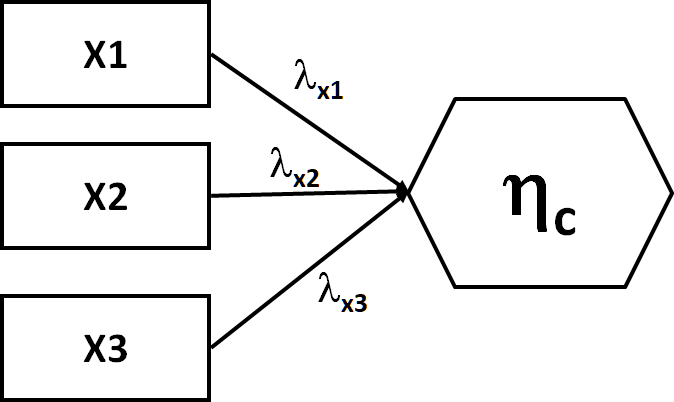

composite variable

Here the arrows are leading *into*, not out of, $\eta$, indicating that the composite variable is made up of the influences of the three example variables. Note: in this and other presentations, the composite is denoted by a hexagon, but can sometimes be an oval as it can technically be a form of a latent variable.

If the composite is *entirely* made up of the three influences, it can be said to have no error. An example might be the two levels of a treatment (present/absent) that lead into a single composite variable called ‘Treatment.’ In this case, there are no other levels of treatment because you, as the investigator, did not apply any. Thus the composite ‘Treatment’ captures the full universe of treatment possibilities given the data.

In other cases, the property might arise from the collective influence of variables but is not without error. For example, the idea of soil condition arises from different aspects of the soil: its pH, moisture, grain size, and so on. However, one might measure only some of these, and thus there remain other factors (nitrogen content) that might contribute to the notion of soil condition. In this case, the composite *would* have error and is therefore known as a *latent composite*.

The benefit of such an approach is that complicated ideas can be distilled into discrete *blocks* that are easier to present and discuss. For example, it is easier to talk about the effects of the experimental treatment on soil condition, rather than the effect of treatment 1 on soil moisture, the effect of treatment 1 on soil pH, the effect of treatment 1 on soil grain size, and so on.

In this way, the composite harkens back to the early meta-model, or broad conceptual relationships that inform the parameterization of the structural path model. In fact, in populating the meta-model, you may wish to consider those broad concepts as composites when fitting the model, rather than modeling all relationships among all observed variables.

Selecting between latent and composite variables comes down to the concept in question, the presumed direction of causality, and the nature of the indicators.

For the soil example, consider: is it that there is a common difference among soils driving variation in pH, moisture, etc.? Or is it that pH, moisture, etc. are all independent properties that combine to inform soil condition? If the goal is measure plant growth in potting soils from different manufacturers, then manufacturer might be the common source of variation and a latent variable more appropriate. If the observer is visiting different sites and measuring conditions that describe the soil in each place, then perhaps a composite variable is warranted.

Another way of thinking about this is whether the indicators are interchangeable. In other words, does soil pH tell us the same information as soil moisture? If so, then they might be indicators of the same latent phenomenon. If not, and they contain unique information, then they likely combine to form a composite variable.

Finally, do the indicators co-vary? If they are under common control of a latent variable, then changing one should alter all the others. If they are relatively independent–for example, one can change grain size without changing nutrient content–then causation likely flows into a composite (rather than out of a latent) variable.

Now that we have defined a composite variable, let’s see how to make one.

## 1.2 Constructing a Composite Variable

Compared to latent variables, a composite variable is actually very easy to estimate: it is simply the sum of its indicators, hence the term *composite*.

The way in which the indicators are summed depends on whether they are expected to have the same weight (a *fixed composite*) or different weights (a *statistical composite*). The former might be something like species relative abundances. The latter is what we will focus on here.

The weights for the composite are easily acquired as they are the values that maximize the explained variance in some response. We have done this before many times using maximum-likelihood fitting.

In fact, statistical composites can be boiled down to the coefficients from a multiple regression. The ML fitting function chooses parameter estimates for each predictor that maximize the likelihood of obseving the response. Those values serve as the loadings for the indicators of the composite variable. The data for each indicator are multipled by their loading and summed to generate the factor scores for the composite variable, which is then used in the structural model.

Let’s demonstrate using some random data:

```r
set.seed(8)

y <- rnorm(50)
x1 <- rnorm(50)
x2 <- x1 + runif(50)

# run multiple regression
model <- lm(y ~ x1 + x2)

# get loadings
beta_x1 <- summary(model)$coefficients[2, 1]

beta_x2 <-  summary(model)$coefficients[3, 1]

# compute factor scores
composite <- beta_x1 * x1 + beta_x2 * x2
```

These values can then used to predict the response:

```r
summary(lm(y ~ composite))
```

```
##
## Call:
## lm(formula = y ~ composite)
##
## Residuals:
##      Min       1Q   Median       3Q      Max
## -2.88387 -0.70164  0.05644  0.54393  2.07769
##
## Coefficients:
##             Estimate Std. Error t value Pr(>|t|)
## (Intercept)  -0.3031     0.2424  -1.250    0.217
## composite     1.0000     0.8045   1.243    0.220
##
## Residual standard error: 1.014 on 48 degrees of freedom
## Multiple R-squared:  0.03118,    Adjusted R-squared:  0.011
## F-statistic: 1.545 on 1 and 48 DF,  p-value: 0.2199
```

Note how the unstandardized coefficient is 1. This is because we the composite is essentially the predicted values of the response, so they are in the same units. Thus, the coefficient is really only interpretable in standardized units.

Let’s alternately fit this composite model with *lavaan* and fix the loadings of $x1$ and $x2$ to the values from the multiple regression:

```r
library(lavaan)
comp_formula1 <- '
composite <~ -0.498 * x1 + 0.579 * x2

y ~ composite
'

comp_model1 <- sem(comp_formula1, data.frame(y, x1, x2))

summary(comp_model1, standardize = T)
```

```
## lavaan 0.6-2 ended normally after 14 iterations
##
##   Optimization method                           NLMINB
##   Number of free parameters                          2
##
##   Number of observations                            50
##
##   Estimator                                         ML
##   Model Fit Test Statistic                       0.000
##   Degrees of freedom                                 1
##   P-value (Chi-square)                           0.999
##
## Parameter Estimates:
##
##   Information                                 Expected
##   Information saturated (h1) model          Structured
##   Standard Errors                             Standard
##
## Composites:
##                    Estimate  Std.Err  z-value  P(>|z|)   Std.lv  Std.all
##   composite <~
##     x1               -0.498                              -2.793   -3.163
##     x2                0.579                               3.248    3.642
##
## Regressions:
##                    Estimate  Std.Err  z-value  P(>|z|)   Std.lv  Std.all
##   y ~
##     composite         1.000    0.788    1.269    0.205    0.178    0.177
##
## Variances:
##                    Estimate  Std.Err  z-value  P(>|z|)   Std.lv  Std.all
##    .y                 0.987    0.197    5.000    0.000    0.987    0.969
##     composite         0.000                               0.000    0.000
```

Let’s suppose we didn’t know the loadings from the multiple regression. We run into the same issue of identifiability as when constructing latent variables, so we must fix the first loading to 1. This will also define the scale of the copmosite. NOTE: *lavaan* does not do this automatically, we will have to implement it manually.

```r
comp_formula2 <- '
composite <~ 1 * x1 + x2

y ~ composite
'

comp_model2 <- sem(comp_formula2, data.frame(y, x1, x2))
```

One solution is to set the other loading to 1:

```r
comp_formula3 <- '
composite <~ x1 + 1 * x2

y ~ composite
'

comp_model3 <- sem(comp_formula3, data.frame(y, x1, x2))

summary(comp_model3)
```

```
## lavaan 0.6-2 ended normally after 22 iterations
##
##   Optimization method                           NLMINB
##   Number of free parameters                          3
##
##   Number of observations                            50
##
##   Estimator                                         ML
##   Model Fit Test Statistic                       0.000
##   Degrees of freedom                                 0
##   Minimum Function Value               0.0000000000000
##
## Parameter Estimates:
##
##   Information                                 Expected
##   Information saturated (h1) model          Structured
##   Standard Errors                             Standard
##
## Composites:
##                    Estimate  Std.Err  z-value  P(>|z|)
##   composite <~
##     x1               -0.860    0.230   -3.745    0.000
##     x2                1.000
##
## Regressions:
##                    Estimate  Std.Err  z-value  P(>|z|)
##   y ~
##     composite         0.579    0.489    1.184    0.236
##
## Variances:
##                    Estimate  Std.Err  z-value  P(>|z|)
##    .y                 0.987    0.197    5.000    0.000
##     composite         0.000
```

Here the model converges because the true loading (0.579) is close enough to 1 for the maximum-likelihood fitting function to find it.

For this reason, it is generally recommended that one compute the loadings by hand and fix them in the model. This has an added benefit we will get to in section 1.4. But first let’s explore a real-world example.

## 1.3 Grace & Keeley Revisited: A Worked Example

Recall from the chapter on “Global Estimation” that Grace & Keeley (2006) were interested in the factors that mediated recovery of shrublands post-fire disturbance. In that chapter, we fit a sub-model of their larger model, and we’ll fit a different sub-model in this chapter.

In their model, they used plant cover to predict plant species richness. Let’s assume for a moment that the relationship between cover and richness may be non-linear: its not until a certain amount of cover that rarer species begin to appear, for example. In this case, we might suppose there are both linear $cover$ and non-linear $cover^2$ components to the model. Composite variables are a nice way to summarize both the linear and non-linear effects.

Let’s fit the following composite variable:

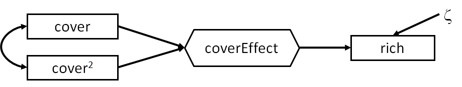

keeley composite

Here we have a composite that summarizes the unsquared and squared values of cover, which then goes on to predict richness.

Let’s adopt the two-step approach and first fit a linear model.

```r
library(piecewiseSEM)
data(keeley)

cover_model <- lm(rich ~ cover + I(cover^2), keeley)

summary(cover_model)
```

```
##
## Call:
## lm(formula = rich ~ cover + I(cover^2), data = keeley)
##
## Residuals:
##     Min      1Q  Median      3Q     Max
## -29.161 -11.958  -0.595  10.094  32.956
##
## Coefficients:
##             Estimate Std. Error t value Pr(>|t|)
## (Intercept)   25.641      6.574   3.900 0.000189 ***
## cover         57.999     18.931   3.064 0.002910 **
## I(cover^2)   -28.577     12.385  -2.307 0.023403 *
## ---
## Signif. codes:  0 '***' 0.001 '**' 0.01 '*' 0.05 '.' 0.1 ' ' 1
##
## Residual standard error: 14 on 87 degrees of freedom
## Multiple R-squared:  0.1598, Adjusted R-squared:  0.1404
## F-statistic: 8.271 on 2 and 87 DF,  p-value: 0.0005147
```

It seems both the unsquared and squared values of cover significantly predict richness, so we are justified in including both as indicators to our composite variable. Now we extract the coefficients, use them to generate the factor scores, and finally use those scores to predict richness.

```r
beta_cover <- summary(cover_model)$coefficients[2, 1]

beta_cover2 <- summary(cover_model)$coefficients[3, 1]

composite <- beta_cover * keeley$cover + beta_cover2 * (keeley$cover)^2

summary(lm(rich ~ composite, data = data.frame(keeley, composite)))
```

```
##
## Call:
## lm(formula = rich ~ composite, data = data.frame(keeley, composite))
##
## Residuals:
##     Min      1Q  Median      3Q     Max
## -29.161 -11.958  -0.595  10.094  32.956
##
## Coefficients:
##             Estimate Std. Error t value Pr(>|t|)
## (Intercept)  25.6406     5.9516   4.308 4.27e-05 ***
## composite     1.0000     0.2445   4.090 9.51e-05 ***
## ---
## Signif. codes:  0 '***' 0.001 '**' 0.01 '*' 0.05 '.' 0.1 ' ' 1
##
## Residual standard error: 13.93 on 88 degrees of freedom
## Multiple R-squared:  0.1598, Adjusted R-squared:  0.1502
## F-statistic: 16.73 on 1 and 88 DF,  p-value: 9.507e-05
```

As would be expected from the multiple regression, the composite term significantly predicts richness ($P < 0.001$). Let’s use the `coefs` function from *piecewiseSEM* to obtain the standardized coefficient:

```r
coefs(lm(rich ~ composite, data = data.frame(keeley, composite)))
```

```
##   Response Predictor Estimate Std.Error DF Crit.Value P.Value Std.Estimate
## 1     rich composite        1    0.2445 88     4.0904   1e-04       0.3997
##
## 1 ***
```

So a 1 SD change in the total cover effect would result in a 0.400 SD change in plant richness.

We can alternately fit the model with *lavaan* using the same coefficients from the multiple regression:

```r
# create a new non-linear variable for cover^2
keeley$coversq <- keeley$cover^2

keeley_formula1 <- '
composite <~ 58 * cover + -28.578 * coversq

rich ~ composite
'

keeley_model1 <- sem(keeley_formula1, keeley)

summary(keeley_model1, standardize = T)
```

```
## lavaan 0.6-2 ended normally after 12 iterations
##
##   Optimization method                           NLMINB
##   Number of free parameters                          2
##
##   Number of observations                            90
##
##   Estimator                                         ML
##   Model Fit Test Statistic                       0.000
##   Degrees of freedom                                 1
##   P-value (Chi-square)                           1.000
##
## Parameter Estimates:
##
##   Information                                 Expected
##   Information saturated (h1) model          Structured
##   Standard Errors                             Standard
##
## Composites:
##                    Estimate  Std.Err  z-value  P(>|z|)   Std.lv  Std.all
##   composite <~
##     cover            58.000                               9.660    3.048
##     coversq         -28.578                              -4.760   -2.295
##
## Regressions:
##                    Estimate  Std.Err  z-value  P(>|z|)   Std.lv  Std.all
##   rich ~
##     composite         1.000    0.242    4.137    0.000    6.004    0.400
##
## Variances:
##                    Estimate  Std.Err  z-value  P(>|z|)   Std.lv  Std.all
##    .rich            189.597   28.263    6.708    0.000  189.597    0.840
##     composite         0.000                               0.000    0.000
```

We obtain the same standardized coefficient (0.400) as through the manual calculation.

Finally, let’s incorporate the predictive effect of fire severity on cover. Now the composite is endogenous because it is affected by fire severity, and goes on to predict richness.

First, we must fit the model without the composite to get the loadings of $cover$ and $cover^2$.

Because the squared term is not a ‘true’ variable in the model but a convenience for us to explore this non-linearity, we must treat them as exogenous even though they are part of an endogenous composite. *lavaan* automatically models correlations among exogenous variables, but will not do so for the composite indicators. In this case, then, we must manually control for the correlation between $cover^s1$ and $cover$ and $firesev$.

```r
keeley_formula2 <- '
composite <~ 58 * cover + -28.578 * coversq

rich ~ composite

cover ~ firesev

cover ~~ coversq

firesev ~~ coversq
'

keeley_model2 <- sem(keeley_formula2, data.frame(keeley, composite))
summary(keeley_model2, standardize = T, rsq = T)
```

```
## lavaan 0.6-2 ended normally after 45 iterations
##
##   Optimization method                           NLMINB
##   Number of free parameters                          8
##
##   Number of observations                            90
##
##   Estimator                                         ML
##   Model Fit Test Statistic                       4.779
##   Degrees of freedom                                 2
##   P-value (Chi-square)                           0.092
##
## Parameter Estimates:
##
##   Information                                 Expected
##   Information saturated (h1) model          Structured
##   Standard Errors                             Standard
##
## Composites:
##                    Estimate  Std.Err  z-value  P(>|z|)   Std.lv  Std.all
##   composite <~
##     cover            58.000                               9.660    3.048
##     coversq         -28.578                              -4.760   -2.295
##
## Regressions:
##                    Estimate  Std.Err  z-value  P(>|z|)   Std.lv  Std.all
##   rich ~
##     composite         1.000    0.242    4.137    0.000    6.004    0.400
##   cover ~
##     firesev          -0.084    0.018   -4.611    0.000   -0.084   -0.437
##
## Covariances:
##                    Estimate  Std.Err  z-value  P(>|z|)   Std.lv  Std.all
##  .cover ~~
##     coversq           0.122    0.019    6.588    0.000    0.122    0.893
##   coversq ~~
##     firesev          -0.301    0.089   -3.369    0.001   -0.301   -0.380
##
## Variances:
##                    Estimate  Std.Err  z-value  P(>|z|)   Std.lv  Std.all
##    .rich            189.597   28.263    6.708    0.000  189.597    0.840
##    .cover             0.081    0.012    6.708    0.000    0.081    0.809
##     coversq           0.233    0.035    6.708    0.000    0.233    1.000
##     firesev           2.700    0.402    6.708    0.000    2.700    1.000
##     composite         0.000                               0.000    0.000
##
## R-Square:
##                    Estimate
##     rich              0.160
##     cover             0.191
```

Here, we find a good-fitting model ($P = 0.092$). Moreover, we obtain the standardized coefficient for the effect of fire severity on cover $\gamma = -0.437$ and of the composite on richness $\beta = 0.400$, which is the total non-linear effect of cover.

To otain the indirect effect then, we multiply these paths plus the standardized loading $cover$ on the composite: $-0.437 * 3.048 * 0.400 = -0.533$.

## 1.4 Composites in *piecewiseSEM*

For the moment, composites are not directly implemented in *piecewiseSEM* but we hope to introduce that functionality shortly. In the interim, it is easy to compute them by hand, as we have shown above, extract the predicted scores, and use them as any other predictor:

```r
keeley$composite <- composite

keeley_psem <- psem(
  lm(firesev ~ cover, keeley),
  lm(rich ~ composite, keeley)
)

summary(keeley_psem)
```

```
##
## Structural Equation Model of keeley_psem
##
## Call:
##   firesev ~ cover
##   rich ~ composite
##
##     AIC      BIC
##  24.292   39.291
##
## ---
## Tests of directed separation:
##
##              Independ.Claim Estimate Std.Error DF Crit.Value P.Value
##          rich ~ cover + ...   0.0000    8.2481 87     0.0000  1.0000
##   firesev ~ composite + ...  -0.0853    0.0456 87    -1.8710  0.0647
##        rich ~ firesev + ...  -2.1610    0.9979 86    -2.1656  0.0331 *
##
## Global goodness-of-fit:
##
##   Fisher's C = 12.292 with P-value = 0.056 and on 6 degrees of freedom
##
## ---
## Coefficients:
##
##   Response Predictor Estimate Std.Error DF Crit.Value P.Value Std.Estimate
##    firesev     cover  -2.2769    0.4994 88    -4.5594   0e+00      -0.4371
##       rich composite   1.0000    0.2445 88     4.0904   1e-04       0.3997
##
##   ***
##   ***
##
##   Signif. codes:  0 '***' 0.001 '**' 0.01 '*' 0.05
##
## Individual R-squared:
##
##   Response method R.squared
##    firesev   none      0.19
##       rich   none      0.16
```

## References

Grace, J. B., & Keeley, J. E. (2006). A structural equation model analysis of postfire plant diversity in California shrublands. Ecological Applications, 16(2), 503-514.